# Lab 6: Missing Data

SEM in R using lavaan

Kyle M. Lang

Updated: 2026-03-14

In this lab, you will practice methods for dealing with missing data when using [**lavaan**](https://cran.r-project.org/web/packages/lavaan/) to fit latent variable models.

# 1 Preliminaries

## 1.1 Data

For this lab, we will go back to working with the *Eating Attitudes* data from Lab 4. These data are available as [*eating_attitudes.rds*](https://github.com/kylelang/lavaan-e-learning/raw/main/data/eating_attitudes.rds). Unlike the completed version that we analyzed in Lab 4, we will now work with the incomplete version that is actually analyzed in [Enders (2010)](https://www.cms.guilford.com/books/Applied-Missing-Data-Analysis/Craig-Enders/9781606236390).

As before, this dataset includes 400 observations of the following 14 variables. Note that the variables are listed in the order that they appear on the dataset.

- `id`: A numeric ID
- `eat1:eat24`: Seven indicators of a *Drive for Thinness* construct
- `eat3:eat21`: Three indicators of a *Preoccupation with Food* construct
- `bmi`: Body mass index
- `wsb`: A single item assessing *Western Standards of Beauty*
- `anx`: A single item assessing *Anxiety Level*

You can download the original data [here](https://www.appliedmissingdata.com/analyses), and you can access the code used to process the data [here](https://github.com/kylelang/lavaan-e-learning/blob/main/code/lab_prep/process_eating_data.R).

### 1.1.1

**Read in the *eating_attitudes.rds* dataset.**

NOTE:

1. In the following, I will refer to these data as the *EA data*.
2. Unless otherwise specified, the data analyzed in all following questions are the EA data.

### 1.1.2

**Summarize the EA data to get a sense of their characteristics.**

- Pay attention to the missing values.

## 1.2 Missing Data Screening

Before we can make any headway with missing data treatment or substantive analyses, we need to get a handle on the extent of our missing data problem. So, we will begin with some descriptive analysis of the missing data.

### 1.2.1

**Calculate the proportion of missing data for each variable.**

### 1.2.2

**Calculate the covariance coverage rates.**

- You can use the `md.pairs()` function from the [**mice**](https://cran.r-project.org/web/packages/mice/index.html) package to count the number of jointly observed cases for every pair or variables.

### 1.2.3

**Summarize the coverages from 1.2.2.**

Covariance coverage matrices are often very large and, hence, difficult to parse. It can be useful to distill this information into a few succinct summaries to help extract the useful knowledge.

### 1.2.4

**Visualize the covariance coverage rates from 1.2.2.**

As with numeric summaries, visualizations are also a good way to distill meaningful knowledge from the raw information in a covariance coverage matrix.

### 1.2.5

**Visualize the missing data patterns.**

- How many unique response patterns are represented in the EA data?

*HINT*:

- The `plot_pattern()` function from [**ggmice**](https://amices.org/ggmice/index.html) will create a nice visualization of the patterns.
- The `md.pattern()` function from **mice** will create a (somewhat less beautiful) visualization but will return a numeric pattern matrix that you can further analyze.

### 1.2.6

**Calculate the fraction of missing information for the summary statistics.**

The fraction of missing information (FMI) is a crucial statistic for quantifying the extent to which missing data (and their treatment) affect parameter estimates. We generally calculate the FMI for the estimates of our substantive model parameters, but we can also use the FMI as a descriptive tool before fitting any substantive model.

- The FMI for the sufficient statistics (e.g., means, variance, and covariances) of our data can give us a good idea of what level of FMI to expect for models fit to those data.
- With the `fmi()` function from [**semTools**](https://cran.r-project.org/web/packages/semTools/index.html), we can efficiently compute the FMI for sufficient statistics using the FIML-based approach described by [Savalei and Rhemtulla (2012)](https://doi.org/10.1080/10705511.2012.687669).

## 1.3 Naive Analysis

Of course, we can estimate models in **lavaan** without doing anything fancy to the missing data. If we fit a model to incomplete data using **lavaan**, the software will automatically apply listwise deletion to remove any missing data before estimating the model.

Although you should almost never use deletion-based treatments, we’ll start our modeling exercises by fitting a model using the default complete case analysis. Sometimes, something goes wrong with the modeling, and you end up deleting cases accidentally. If you’re keyed into the signs that listwise deletion has occurred, you’ll know what to check when working with these methods in the wild.

### 1.3.1

**Define the model syntax for the CFA.**

The data only contain multi-item scales for *Drive for Thinness* and *Preoccupation with Food*, so we only need a two-dimensional CFA evaluating the measurement structure of these two factors.

- Indicated the *Drive for Thinness* factor from the seven relevant scale items.
  - `eat1`, `eat2`, `eat10`, `eat11`, `eat12`, `eat14`, `eat24`
- Indicated the *Preoccupation with Food* factor from the remaining three scale items.
  - `eat3`, `eat18`, `eat21`

### 1.3.2

**Estimate the CFA model on the EA data.**

- Correlate the latent factors.
- Set the scale by standardizing the latent factors.
- Estimate the mean structure.
- Use complete case analysis to treat the missing data.

### 1.3.3

**Summarize the fitted CFA and check the model fit.**

- Do the parameter estimates look sensible?
- Does the model fit the data well enough?
- How many observations were deleted?

# 2 Multiple Imputation

Now, we’ll get into the real meat of the lab and move into the realm of recommended approaches. Specifically, we will treat the missing data via principled methods that correct the missing data problem through a theoretically motivated model for the missing values.

The first such approach we will consider is *multiple imputation* (MI). MI is a pre-processing method that treats the missing data as a separate step prior to estimating the analysis model. Consequently, the fist step in our journey toward an MI-based analysis will be multiply imputing the missing data.

## 2.1 Imputation

### 2.1.1

**Multiply impute the missing data.**

Use the **mice**::`mice()` function to impute the missing data using the following settings.

- Create 20 imputations.
- Use 25 iterations of the MICE algorithm.
- Use *predictive mean matching* (PMM) as the elementary imputation method.
- Set the pseudo random number seed to 235711.

*HINT*:

- If you are unsure of how to implement these options check the documentation for the `mice()` function.
- If you are really, really stuck, unhide the solution below.

**View the parameterized `mice()` call.**

```r
## Generate 20 imputations of the missing data:
miceOut <- mice(ea, m = 20, maxit = 25, method = "pmm", seed = 235711)
```

### 2.1.2

**Create a list of imputed datasets from the *mids* object generated in 2.1.1.**

The `mice()` function returns a *mids* object that contains the imputations and a bunch of other metadata but not the imputed datasets.

- We use the **mice**::`complete()` function to create the final imputed datasets.
- Return the imputed data as a list (with length 20) of multiply imputed datasets.

## 2.2 Diagnostics

MI operates by filling the missing values with samples from the posterior predictive distribution (PPD) of the missing data. This PPD is essentially just a distribution of predictions generated from some Bayesian regression model. These models are usually estimated via Markov Chain Monte Carlo (MCMC) methods.

MCMC is a stochastic estimation procedure that estimates a probabilistic model by randomly sampling from the joint distribution of the model parameters (the so-called posterior distribution in Bayesian models) to build up an empirical representation of this distribution. When using MCMC, the estimated model (and, in our case, the imputations) is only valid if the MCMC algorithm has converged.

Therefore, before we can proceed with the analysis, we need to check two important criteria:

1. The MCMC algorithm has converged onto a stationary solution (i.e., the MCMC samples represent valid draws from some stable distribution).
2. The imputations are sensible (i.e., they look like reasonable replacements for the missing data).

For more information on MCMC estimation, convergence, and diagnostics for MI models, see Sections [4.5](https://stefvanbuuren.name/fimd/sec-FCS.html), [6.5](https://stefvanbuuren.name/fimd/sec-algoptions.html), and [6.6](https://stefvanbuuren.name/fimd/sec-diagnostics.html) of [Van Buuren (2019)](https://stefvanbuuren.name/fimd/).

### 2.2.1

**Create traceplots of the imputations’ means and variances.**

One especially expedient way to evaluate convergence is by plotting the iteration history of the means and variances of the imputed values for each variable. Once the MCMC algorithm has converged, the individual lines in these plots (each of which corresponds to one imputation and represents an independent Markov Chain) should mix thoroughly, and the overall mass of the tracelines should show no trend.

- Use the `plot_trace()` function from **ggmice** to create traceplots for each imputed variable.
- Do these plots suggest convergence?

We can also evaluate convergence via numeric statistics such as the *Potential Scale Reduction Factor*, $\hat{R}$, ([Gelman & Rubin, 1992](https://doi.org/10.1214/ss/1177011136)).

### 2.2.2

**Compute the $\hat{R}$ statistic for the means and variances of the imputations.**

For *mids* objects, we can use the `Rhat.mice()` function from [**miceadds**](https://cran.r-project.org/web/packages/miceadds/index.html) to compute the $\hat{R}$ statistics for the means and variances of the imputed data.

- At convergence, these statistic should all be close to 1.0 (i.e., $\hat{R} < 1.1$)
- Do the $\hat{R}$ statistics suggest convergence?

After we confirm that the imputation model has converged, we still need to sanity check the imputed values, themselves. A convergent imputation model can still produce completely ridiculous and useless imputations. The fact that the MCMC algorithm has converged onto a stationary distribution does not mean that this distribution represents a sensible imputation model.

One of the best ways to check the plausibility of the imputations is with plots that juxtapose the imputed and observed data. Since we’re comparing distributions of numeric variables, kernel density plots are a good option.

### 2.2.3

**Create kernel density plots of the imputed and observed data.**

We can create “quick-and-dirty” density plots via the **mice**::`densityplot()` function, but **ggmice**::`ggmice()` allows us to create the same figures with all the control provided by `ggplot()`. For more details check [this page](https://amices.org/ggmice/articles/old_friends.html).

- Do the imputed values look reasonable?

# 3 MI-Bases Analysis

Assuming our imputations pass the above checks, it’s time to move into the analysis phase of the process. In practice, we will lean heavily on routines from the [**lavaan.mi**](https://cran.r-project.org/web/packages/lavaan.mi/index.html) package to implement both the analysis and pooling phases.

## 3.1 Basic CFA/SEM

### 3.1.1

**Estimate the CFA defined in 1.3.1 on the multiply imputed data.**

- Correlate the latent factors.
- Set the scale by standardizing the latent factors.
- Estimate the mean structure.

*HINT*: The **lavaan.mi**::`cfa.mi()` function can be a big help here.

### 3.1.2

**Summarize the fitted CFA and check the model fit.**

- Include the FMI statistics in your summary.
- Use the D3 statistic to define the model fit indices.
- Do the parameter estimates look sensible?
- Does the model fit the data well enough?
- Do any of the FMI estimates cause you to question the results?

Now, we will estimate a latent regression model wherein the *preoccupation with food* factor and the *drive for thinness* factor are correlated and regressed onto *anxiety*, *Western beauty standards*, and *BMI*.

### 3.1.3

**Define the model syntax for the SEM described above.**

- Label the regression slopes for *anxiety* and *Western beauty standards*.
  - Give each slope a distinct label (you should end up with four unique labels).
- Do not include the intercepts in the latent regression equations.

### 3.1.4

**Estimate the SEM on the multiply imputed data.**

- Covary the latent factors.
- Set the scale by standardizing the latent variables.

*HINT*: The **lavaan.mi**::`sem.mi()` function can be a big help here.

### 3.1.5

**Summarize the fitted SEM and interpret the results.**

- Include the FMI statistics in your summary.
- Does *anxiety* significantly predict *preoccupation with food* and/or *drive for thinness* after controlling for *Western beauty standards* and *BMI*?
- Does *Western beauty standards* significantly predict *preoccupation with food* and/or *drive for thinness* after controlling for *anxiety* and *BMI*?

## 3.2 Testing

Given an SEM fitted to multiply imputed data via **lavaan.mi**::`lavaan.mi()`, we can use the testing utilities from **lavaan.mi** to evaluate (multivariate) hypotheses defined in terms of parameter constraints.

- In the next two questions, we’ll test one such hypothesis.

### 3.2.1

**Apply a multivariate Wald test to the fitted model from 3.1.4.**

- Test the bivariate null hypothesis that states:
  1. The effect of *anxiety* on both outcomes is equal
  2. The effect of *Western beauty standards* on both outcomes is equal
- Use the $D1$ statistic to conduct the test.
- What is the conclusion of this test?

*HINT*: The **lavaan.mi**::`lavTestWald.mi()` function can be very helpful here.

### 3.2.2

**Test the hypothesis from 3.2.1 using a likelihood ratio test (LRT).**

- Estimate a separate restricted SEM using the multiply imputed data.
- Compare the full and restricted fits using a LRT.
- Use the $D3$ statistic to conduct the test.
- What is the conclusion of this test?

## 3.3 Mediation

Next, we’ll consider methods for modeling mediation when working with MI data. To keep things simple, we’re only going to estimate wherein *Western beauty standards* predict *preoccupation with food*, and *drive for thinness* mediates this relation.

- You can see the path diagram for this model below.

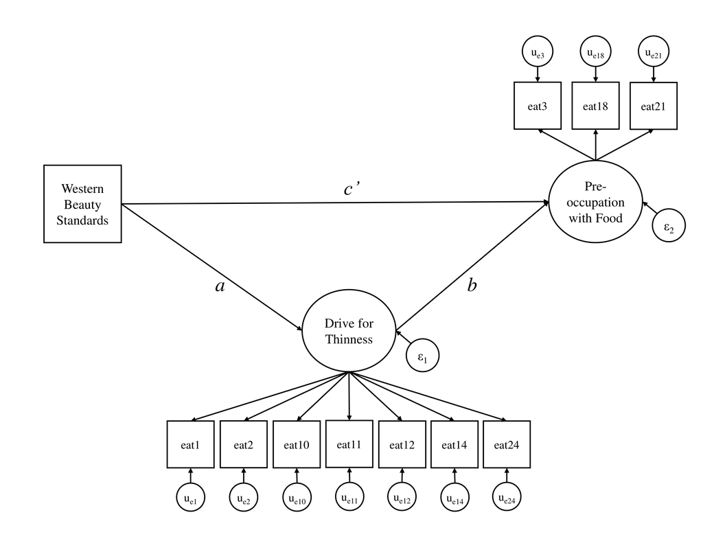

### 3.3.1

**Define the model syntax for the structural model.**

- Specify all paths needed to test the mediation hypothesis described above.
- Include a defined parameter to quantify the indirect effect.

Combining mediation with MI is a bit tricky. When treating the missing data with MI, we produce $M$ different datasets, but we also need to create $B$ bootstrap samples to test the indirect effects. The best method for combining these two layers of sampling is not immediately obvious, but the literature does provide some guidance. [Wu and Jia (2013)](https://doi.org/10.1080/00273171.2013.816235) recommend nesting bootstrapping within MI via an approach that they call *MI(Boot)*. The MI(Boot) procedure entails the following steps.

1. Impute the missing data $M$ times.
2. For each of these $M$ imputed datasets, estimate your mediation model as you would on fully observed data.
   - I.e., use $B$ bootstrap samples to quantify the uncertainty.
3. Combine the $M \times B$ resulting estimates of the indirect effect into a single sample with $N = M \times B$ observations.
4. Treat this aggregated sample as a single pool of bootstrapped estimates and construct CIs in the usual way.

The MI(Boot) approach is not currently implemented in **lavaan** or **semTools** (neither is any alternative method of combining MI and bootstrapping). If you really wanted to, however, you could implement MI(Boot) manually.

- The following three code chunks demonstrate one potential implementation.

First, we’ll define a function that will take a fitted lavaan object (`lavObj`) as input and return the bootstrapped estimates of all defined parameters specified in the model syntax of `lavObj`.

```r
getDefParEstimates <- function(lavObj) {
  ## Use lavaan::lav_partable_constraints_def() to generate a function that
  ## computes all defined parameters represented in 'lavObj':
  getDefPar <- lavObj |> parTable() |> lav_partable_constraints_def()

  ## Extract the bootstrapped coefficient estimates from 'lavObj':
  cf <- inspect(lavObj, "coef.boot")

  ## Compute the defined parameters on each bootstrapped sample:
  apply(cf, 1, getDefPar)
}
```

Now, we’ll use the `semList()` function from **lavaan** to fit `semMod3` to each of the M = 20 imputed datasets in `eaImp`.

- We’ll generate B = 1000 bootstrap samples for each of these 20 imputed datasets.
- We’ll use the `getDefParEstimates()` function defined above to extract the relevant estimates (i.e., the bootstrapped estimates of the indirect effect) from each one of our 20 fitted lavaan objects.

*NOTE*: This code will take quite a long time to run. So, if you want to run the code yourself, consider first doing so with a small number of bootstrap samples (e.g., $B = 50$) to get a sense of the run time to expect.

- If you want a more accurate estimate, you can time this baby run with `system.time()` and extrapolate from there.

```r
## Variable to set the number of bootstrap samples:
nBoot <- 1000

## Fit the models:
fits <- semList(semMod3,
                dataList  = eaImp,
                std.lv    = TRUE,
                se        = "boot",
                bootstrap = nBoot,
                FUN       = getDefParEstimates)
```

Finally, we aggregate the bootstrapped estimates of the indirect effect from above (these live in the `funList` slot of the `fits` object) into a single sample with $N = 20 \times 1000 = 20000$ observations.

- This aggregated pool of estimates represents the empirical sampling distribution of our indirect effect, so we can summarize this aggregated sample for inference (e.g., by compute the 95% CI of the indirect effect).

```r
## Aggregate estimates:
ab <- fits@funList |> unlist()

## Calculate a basic percentile CI for the indirect effect:
quantile(ab, c(0.025, 0.975))
```

```
     2.5%     97.5%
0.1030509 0.2153346
```

The MI(Boot) approach will produce theoretically optimal results, but it does so at a high computational cost. Implementing the approach for **lavaan** models is also a bit tricky. Thankfully, we have a very satisfactory alternative: the Monte Carlo method proposed by [MacKinnon et al. (2004)](https://doi.org/10.1207/s15327906mbr3901_4).

The justification for the Monte Carlo method begins with the original motivation for using bootstrapping to test the indirect effect: the $a$ and $b$ paths are normally distributed, so their product cannot be. Rather than going fully non-parametric (as in bootstrapping), though, the Monte Carlo method leverages the known sampling distributions of $a$ and $b$ to synthesize an empirical sampling distribution of their product (i.e., the indirect effect). The Monte Carlo method entails the following procedure.

1. Estimate the mediation model on the full dataset.
   - For MI data, this model is estimated in the usual way, and the parameter estimates used in the following steps are the pooled MI estimates.
2. Use the estimated $a$ and $b$ paths along with their asymptotic covariance matrix to define a bivariate normal distribution.
   - This distribution represents an estimate of the joint sampling distribution of $a$ and $b$ under the assumption of bivariate normality (which is usually a reasonable assumption).
3. Generate a very large sample (e.g., $N \geq 20000$) from the bivariate normal distribution defined above.
   - Although we need to generate a very large sample here, generating such a sample is computationally trivial and very fast.
4. For each $\{a_n, b_n\}$ pair in the above sample, compute the indirect effect, $ab_n = a_n \times b_n$.
5. Use the $N$ estimates of the indirect effect to define an empirical sampling distribution, and summarize this distribution as you would if the sample had been generated by ordinary bootstrapping.

Fortunately for us, the Monte Carlo simulation approach is implemented in the `monteCarloCI()` function from **semTools**. For more information on this approach, see [MacKinnon et al. (2004)](https://doi.org/10.1207/s15327906mbr3901_4) and [Preacher and Selig (2012)](https://doi.org/10.1080/19312458.2012.679848).

### 3.3.2

**Use the Monte Carlo simulation approach to test the above mediation hypothesis.**

- Is the indirect effect statistically significant?

# 4 FIML

Now that we’ve had our fun with MI, lets explore the final topic of this lab: *full information maximum likelihood* (FIML).

## 4.1 Basic FIML

### 4.1.1

**Estimate the CFA defined in 1.3.1 using FIML.**

- Fit the model to the incomplete EA data.
- Correlate the latent variables.
- Estimate the mean structure.
- Set the scale by standardizing the latent variables.

### 4.1.2

**Summarize the fitted model.**

- Include the FMI statistics in your summary
  - Do any of these FMI values give you pause?
  - How do these FMI estimates compare to those from the MI-based CFA in 3.1.1?
- Does the number of missing data patterns shown in the summary match the number you calculated in 1.2.5?
  - If not, what do you think causes this discrepancy?
- Do the parameter estimates looks sensible?
- Does the model fit the data well enough?

## 4.2 Auxiliary Variables

Although the model above seems to have produced satisfactory estimates, the MAR assumption will have been violated unless the missingness on the indicators of `drive` and `pre` is associated only with other such indicators. If, for example, missingness on some of the `pre` items is associated with *BMI*, then the data are MNAR, and the model estimates are probably biased.

- We can address this issue by including auxiliary variables (i.e., potential correlates of missingness in which we have no substantive interest) via the [Graham (2003)](https://doi.org/10.1207/S15328007SEM1001_4) saturated correlates technique.

### 4.2.1

**Rerun the CFA using `bmi`, `anx`, and `wsb` as auxiliary variables.**

- Include the auxiliaries via the saturated correlates approach.
- Keep all other model parameterization and estimation settings the same as above.

*HINT*: The **semTools**::`cfa.auxiliary()` function can be very helpful here.

### 4.2.2

**Summarize the CFA model and check the model fit.**

- How do the results compare to the model estimated without auxiliary variables?

## 4.3 Fixed vs. Random $X$

### 4.3.1

**Use FIML to estimate the latent regression model defined in 3.1.3.**

- Correlate the latent factors.
- Set the scale by standardizing the latent variables.
- Did anything unusual/unexpected happen during model estimation?
  - If you do see some unusual behavior, can you explain what happened?

### 4.3.2

**Summarize the fitted SEM.**

- Include the FMI estimates in the summary.
- How do the latent regression results compare to those from the MI-based Model?

### 4.3.3

**Rerun the model from 4.3.1 with random predictors.**

- Model the observed predictor variables as random by setting `fixed.x = FALSE` in the `sem()` call.
- Keep all other settings the same as above.

### 4.3.4

**Summarize the fitted SEM from 4.3.3.**

- What differences do you notice between the fixed-$X$ and random-$X$ fits?
- Which of these two models do you think is more appropriate and why?

## 4.4 Mediation

### 4.4.1

**Use FIML to estimate the mediation model defined in 3.3.1.**

- Include `bmi` and `anx` as auxiliary variables.
- Use B = 1000 bootstrap resamples to quantify the sampling variability.

*NOTE*: This code will take a long time to run. You may want to consider using the run timing strategies discussed in the MI(Boot) section.

### 4.4.2

**Summarize the fitted mediation model and interpret the results.**

- Is the indirect effect through *Drive for Thinness* significant according to the 95% BC CI?
- Briefly interpret the indirect effects.

End of Lab 6